# Implementing a POMP model from scratch

Aaron A. King and Edward L. Ionides

The **R** codes for this document are provided as a script.

This document has its origins in the [Getting Started vignette](https://kingaa.github.io/pomp/vignettes/getting_started.html).

## Introduction

The **R** package **pomp** provides facilities for modeling POMPs, a toolbox of statistical inference methods for analyzing data using POMPs, and a development platform for implmenting new POMP inference methods. The basic data-structure provided by **pomp** is the *object of class* `pomp`, alternatively known as a `pomp` object. It is a container that holds real or simulated data and a POMP model, possibly together with other information such as model parameters, that may be needed to do things with the model and data. A real **pomp** data analysis begins with constructing one or more `pomp` objects to hold the data and the model or models under consideration. Here, we’ll illustrate this process a dataset of *Parus major* abundance in Wytham Wood, near Oxford (McCleery and Perrins 1991).

Download and plot the data:

```r
loc <- url("https://kingaa.github.io/sbied/intro/parus.csv")
dat <- read.csv(loc)
head(dat)
```

```
 year pop
 1960 148
 1961 258
 1962 185
 1963 170
 1964 267
 1965 239
```

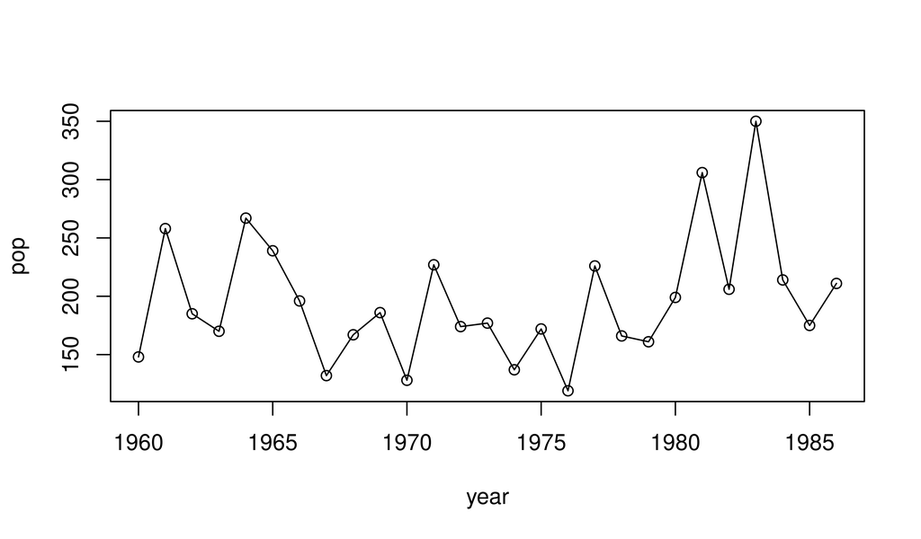

```r
plot(pop~year,data=dat,type='o')
```

## A stochastic Ricker model

Let’s suppose we wish to investigate the extent to which the Ricker model (Ricker 1954) explains these data. First, let’s recall the details of the Ricker (1954) model.

#### The deterministic Ricker map

The Ricker map describes the deterministic dynamics of a simple population:
$$N_{t+1} = r\,N_{t}\,\exp(-c\,N_{t}).$$
Here, $N_t$ is the population density at time $t$ and $r$ is a fixed value, related to the population’s intrinsic capacity to increase. $N$ is a *state variable*, $r$ and $c$ are *parameters*. If we know $r$ and the *initial condition* $N_0$, the deterministic Ricker equation predicts the future population density at all times $t=1,2,\dots$. We can view the initial condition, $N_0$ as a special kind of parameter, an *initial-value parameter*.

#### Process noise

We can model process noise in this system by making the growth rate $r$ into a random variable. For example, if we assume that the intrinsic growth rate is log-normally distributed, $N$ becomes a stochastic process governed by
$$N_{t+1} = r\,N_{t}\,\exp(-c\,N_{t}+\varepsilon_{t}), \qquad \varepsilon_{t}\;\sim\;\mathrm{Normal}\left(0,\sigma\right),$$
where the new parameter $\sigma$ is the standard deviation of the noise process $\varepsilon$.

#### Measurement error

Let’s suppose that the Ricker model is our model for the dynamics of a real population. However, we cannot know the exact population density at any time, but only estimate it through sampling.

Let’s model measurement error by assuming the measurements, $y_t$, are Poisson with mean $\phi\,N_t$:
$$y_{t}\;\sim\;\mathrm{Poisson}\left(\phi\,N_{t}\right)$$

In this equation,

1. $N_t$ is the true population density at time $t$,
2. $y_t$ is the number of individuals sampled at time $t$,
3. the choice of units for $N$ is peculiar and depends on the parameters (e.g., $N=\log(r)/c$ is the equilibrium of the deterministic model),
4. the parameter $\phi$ is proportional to our sampling effort, and also has peculiar units.

## Implementing the Ricker model in **pomp**

The call to construct a `pomp` object is, naturally enough, `pomp`. Documentation on this function can be had by doing `?pomp`. Learn about the various things you can do once you have a `pomp` object by doing `methods?pomp` and following the links therein. Read an overview of the package as a whole with links to its main features by doing `package?pomp`. A complete index of the functions in **pomp** is returned by the command `library(help=pomp)`. Finally, the home page for the `pomp` project is https://kingaa.github.io/pomp/; there you have access to the complete source code, tutorials, manuals, a news blog, a facility for reporting issues and making help requests, etc.

Now, to construct our `pomp` object:

```r
library(pomp)
parus <- pomp(dat,times="year",t0=1959)
```

The `times` argument specifies that the column of `dat` labelled “year” gives the measurement times; `t0` is the “zero-time”, the time at which the state process will be initialized. We’ve set it to one year prior to the beginning of the data. Plot the new `pomp` object:

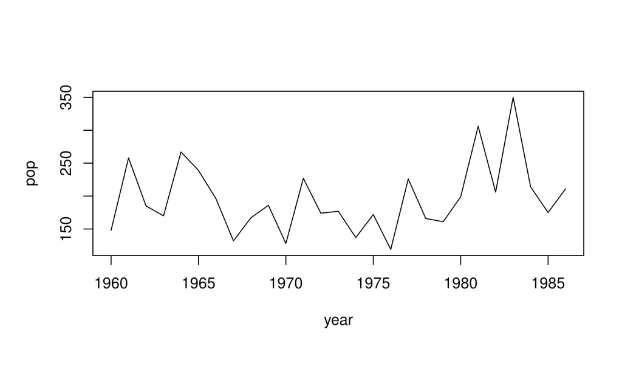

```r
plot(parus)
```

### Adding in the process model simulator

We can add the stochastic Ricker model to `parus` by writing a Csnippet that simulates one realization of the stochastic process, from an arbitary time $t$ to $t+1$, given arbitrary states and parameters. We provide this to `pomp` in the form of a `Csnippet`, a little snippet of C code that performs the computation. The following does this.

```r
stochStep <- Csnippet("
  e = rnorm(0,sigma);
  N = r*N*exp(-c*N+e);
")
pomp(parus,rprocess=discrete_time(step.fun=stochStep,delta.t=1),
     paramnames=c("r","c","sigma"),statenames=c("N","e")) -> parus
```

At this point, we have what we need to simulate the state process:

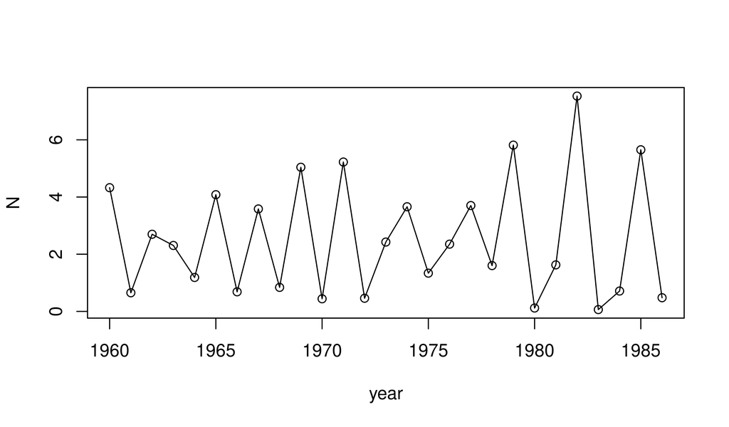

```r
sim <- simulate(parus,params=c(N_0=1,e_0=0,r=12,c=1,sigma=0.5),
                format="data.frame")
plot(N~year,data=sim,type='o')
```

### Adding in the measurement model and parameters

We complete the specification of the POMP by specifying the measurement model. To obtain the Poisson measurement model described above, we write two Csnippets. The first simulates:

```r
rmeas <- Csnippet("pop = rpois(phi*N);")
```

The second computes the likelihood of observing `pop` birds given a true density of `N`:

```r
dmeas <- Csnippet("lik = dpois(pop,phi*N,give_log);")
```

[Note the `give_log` argument. When this code is evaluated, `give_log` will be set to 1 if the log likelihood is desired, and 0 else.] We add these into the `pomp` object:

```r
pomp(parus,rmeasure=rmeas,dmeasure=dmeas,statenames=c("N"),paramnames=c("phi")) -> parus
```

Now we can simulate the whole POMP. First, let’s add some parameters:

```r
coef(parus) <- c(N_0=1,e_0=0,r=20,c=1,sigma=0.1,phi=200)
```

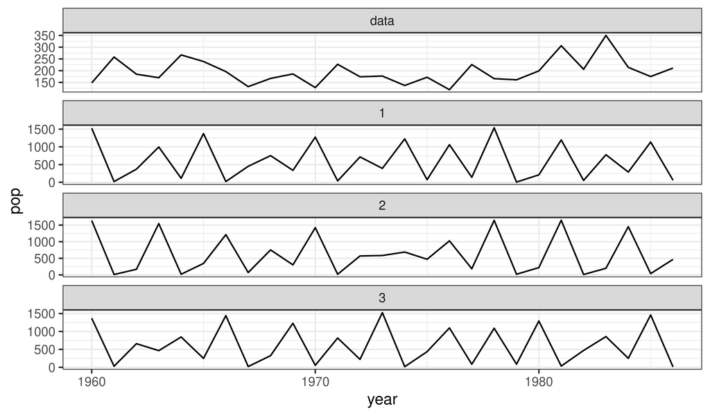

```r
library(ggplot2)
sims <- simulate(parus,nsim=3,format="d",include.data=TRUE)
ggplot(data=sims,mapping=aes(x=year,y=pop))+geom_line()+
  facet_wrap(~.id,ncol=1,scales="free_y")
```

### Adding in the deterministic skeleton

We can add the Ricker model deterministic skeleton to the `parus` `pomp` object. Since the Ricker model is a discrete-time model, its skeleton is a map that takes $N_t$ to $N_{t+1}$ according to the Ricker model equation
$$N_{t+1} = r\,N_{t}\,\exp(-c\,N_{t}).$$
The following implements this.

```r
skel <- Csnippet("DN = r*N*exp(-c*N);")
```

We then add this to the `pomp` object:

```r
parus <- pomp(parus,skeleton=map(skel),paramnames=c("r","c"),statenames=c("N"))
```

Note that we have to inform **pomp** as to which of the variables we’ve referred to in `skel` is a state variable (`statenames`) and which is a parameter (`paramnames`). In writing a `Csnippet` for the deterministic skeleton, we use `D` to designate the map’s value. The `map` call tells **pomp** that the skeleton is a discrete-time dynamical system (a map) rather than a continuous-time system (a vectorfield).

With just the skeleton defined, we are in a position to compute the trajectories of the deterministic skeleton at any point in parameter space. For example, here we compute the trajectory and superimpose it on a plot of one simulation:

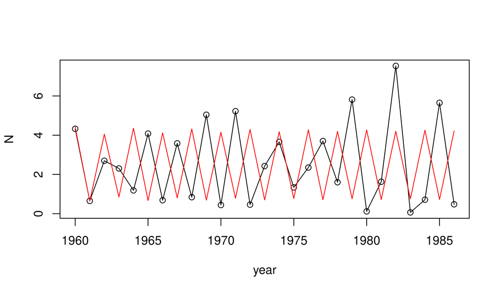

```r
traj <- trajectory(parus,params=c(N_0=1,r=12,c=1),format="data.frame")
plot(N~year,data=sim,type='o')
lines(N~year,data=traj,type='l',col='red')
```

## Working with the Ricker model in **pomp**.

Let’s see what can be done with a `pomp` object.

We can plot the data by doing

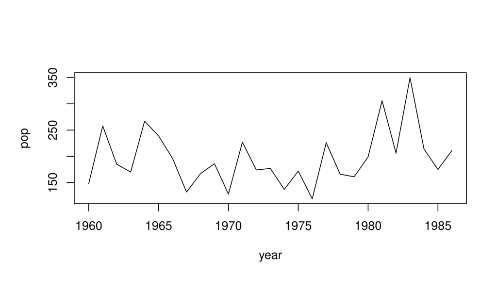

```r
plot(parus)
```

We can simulate by doing

```r
x <- simulate(parus)
```

What kind of object have we created with this call to `simulate`?

```r
class(x)
```

```
[1] "pomp"
attr(,"package")
[1] "pomp"
```

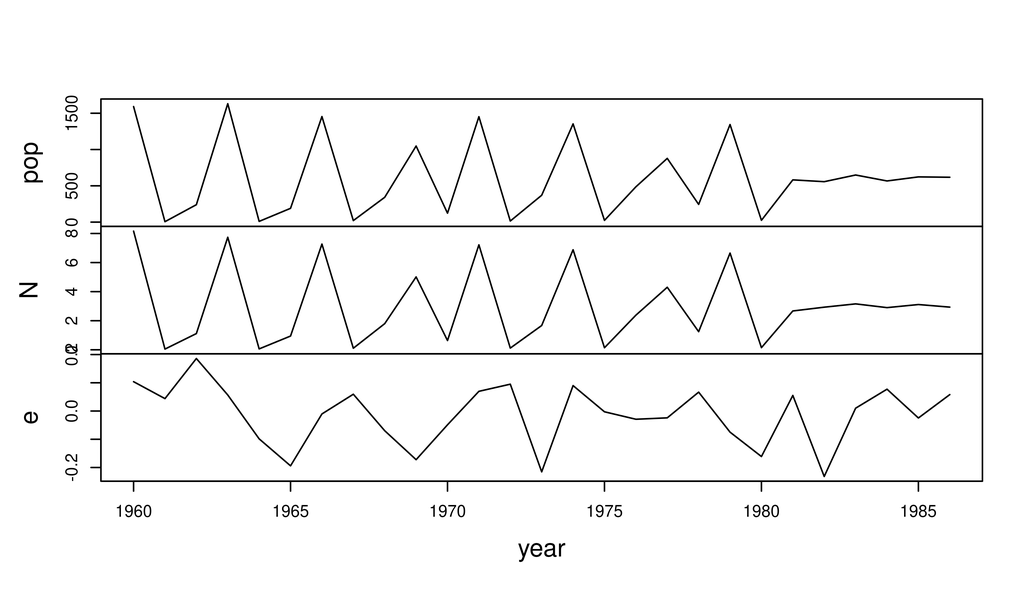

```r
plot(x)
```

Why do we see more time series in the simulated `pomp` object?

We can turn a `pomp` object into a data frame:

```r
y <- as.data.frame(parus)
head(y)
```

```
 year pop
 1960 148
 1961 258
 1962 185
 1963 170
 1964 267
 1965 239
```

```r
head(simulate(parus,format="data.frame"))
```

```
 year .id          N           e  pop
 1960   1 8.63697074 0.160319639 1767
 1961   1 0.03094742 0.009720897    4
 1962   1 0.65458001 0.086919344  115
 1963   1 7.64889406 0.117170263 1535
 1964   1 0.08470427 0.150011503   19
 1965   1 1.61665754 0.037921980  299
```

We can also run multiple simulations simultaneously:

```r
x <- simulate(parus,nsim=10)
class(x)
```

```
[1] "pompList"
attr(,"package")
[1] "pomp"
```

```r
sapply(x,class)
```

```
 [1] "pomp" "pomp" "pomp" "pomp" "pomp" "pomp" "pomp" "pomp"
 [9] "pomp" "pomp"
```

```r
x <- simulate(parus,nsim=10,format="data.frame")
head(x)
```

```
 year .id        N           e  pop
 1960   1 6.385684 -0.14167360 1293
 1960   2 9.349268  0.23956583 1888
 1960   3 6.594032 -0.10956728 1272
 1960   4 7.100530 -0.03556291 1491
 1960   5 6.911126 -0.06259967 1418
 1960   6 7.493781  0.01834121 1496
```

```r
str(x)
```

```
'data.frame':   270 obs. of  5 variables:
 $ year: num  1960 1960 1960 1960 1960 1960 1960 1960 1960 1960 ...
 $ .id : Ord.factor w/ 10 levels "1"<"2"<"3"<"4"<..: 1 2 3 4 5 6 7 8 9 10 ...
 $ N   : num  6.39 9.35 6.59 7.1 6.91 ...
 $ e   : num  -0.1417 0.2396 -0.1096 -0.0356 -0.0626 ...
 $ pop : num  1293 1888 1272 1491 1418 ...
```

Also,

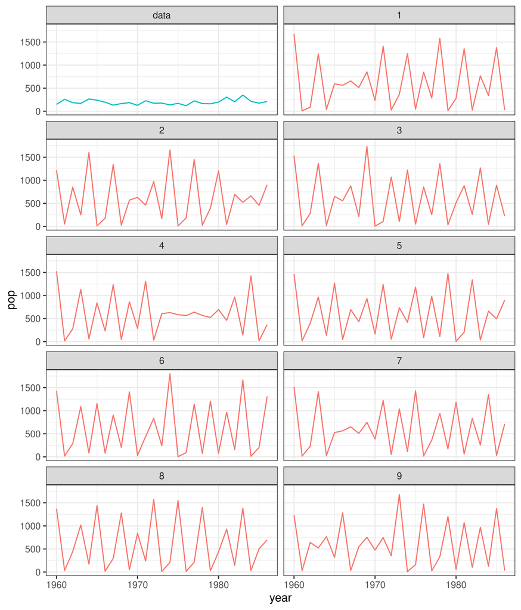

```r
library(ggplot2)
x <- simulate(parus,nsim=9,format="data.frame",include.data=TRUE)
ggplot(data=x,aes(x=year,y=pop,group=.id,color=(.id=="data")))+
  geom_line()+guides(color="none")+
  facet_wrap(~.id,ncol=2)
```

We refer to the deterministic map as the “skeleton” of the stochastic process. We can compute a trajectory of the the deterministic skeleton using `trajectory`:

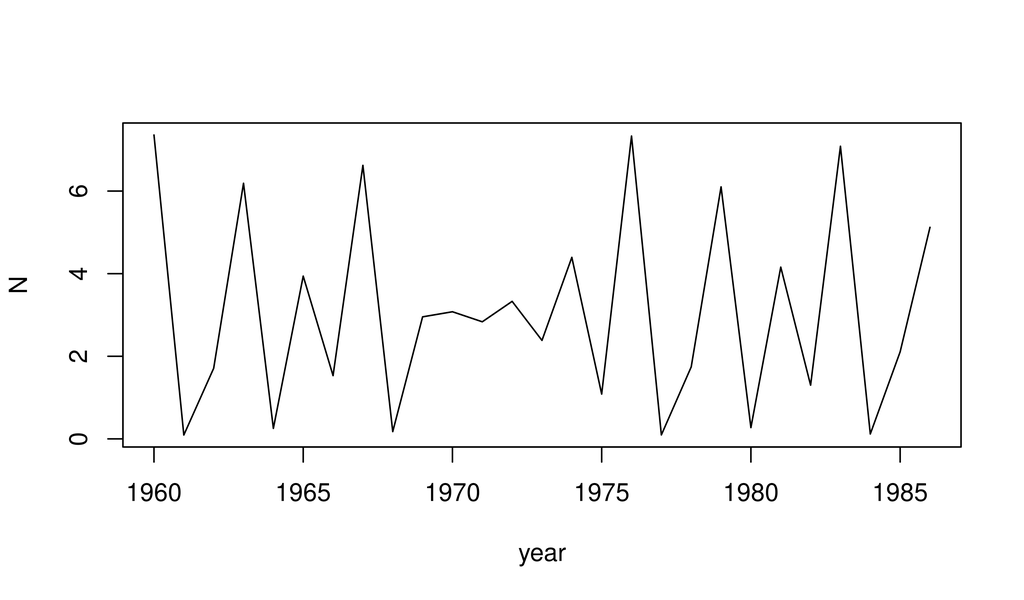

```r
y <- trajectory(parus,format="data.frame")
plot(N~year,data=y,type="l")
```

Notice that `parus` has parameters associated with it:

```r
coef(parus)
```

```
  N_0   e_0     r     c sigma   phi
  1.0   0.0  20.0   1.0   0.1 200.0
```

These are the parameters at which the simulations and deterministic trajectory computations above were done. We can run these at different parameters:

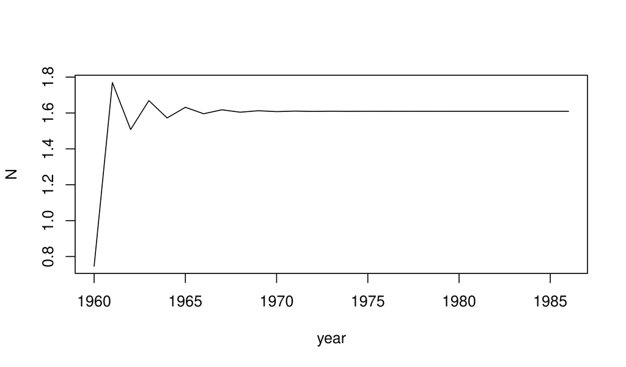

```r
theta <- coef(parus)
theta[c("r","N_0")] <- c(5,3)
y <- trajectory(parus,params=theta)
plot(N~year,data=as.data.frame(y),type='l')
```

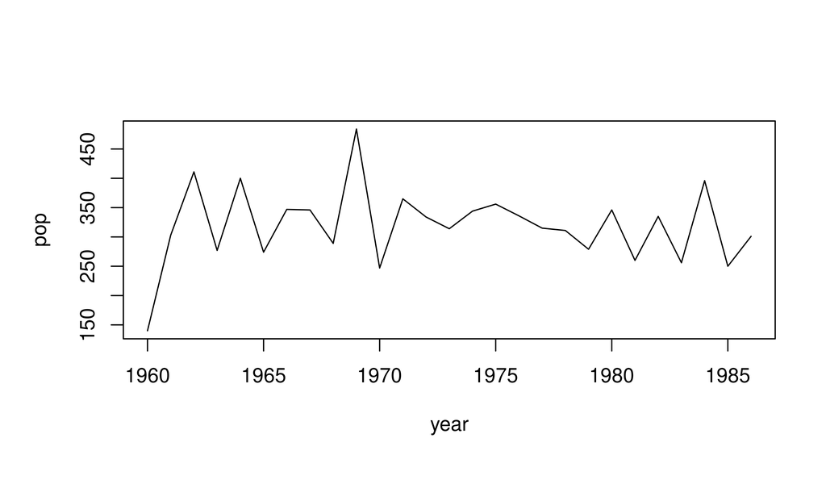

```r
x <- simulate(parus,params=theta)
plot(x,var="pop")
```

We can also change the parameters stored inside of `parus`:

```r
coef(parus,c("r","N_0","sigma")) <- c(39,0.5,1)
coef(parus)
```

```
  N_0   e_0     r     c sigma   phi
  0.5   0.0  39.0   1.0   1.0 200.0
```

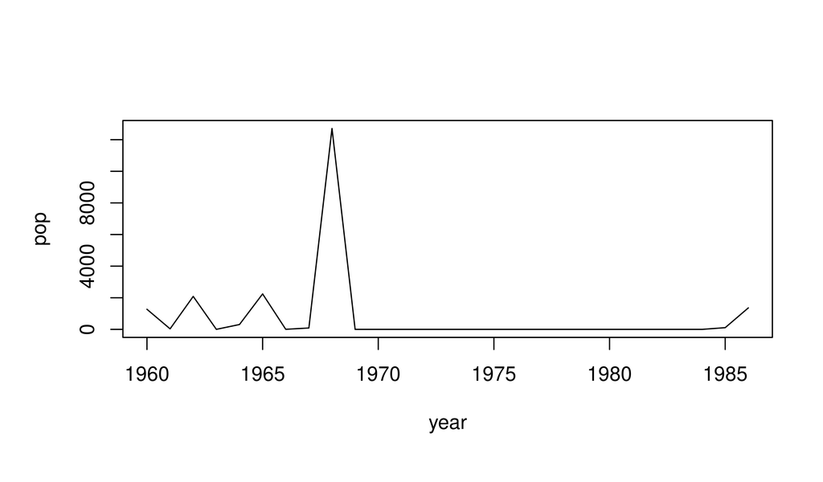

```r
plot(simulate(parus),var="pop")
```

### A note on terminology

If we know the state, $x(t_0)$, of the system at time $t_0$, it makes sense to speak about the entire trajectory of the system for all $t>t_0$. This is true whether we are thinking of the system as deterministic or stochastic. Of course, in the former case, the trajectory is uniquely determined by $x(t_0)$, while in the stochastic case, only the probability distribution of $x(t)$, $t>t_0$ is determined. To avoid confusion, we use the term “trajectory” exclusively to refer to *trajectories of a deterministic process*. Thus, the `trajectory` command iterates or integrates the deterministic skeleton forward in time, returning the unique trajectory determined by the specified parameters. When we want to speak about sample paths of a stochastic process, we use the term *simulation*. Accordingly, the `simulate` command always returns individual sample paths from the POMP. In particular, we avoid “simulating a set of differential equations”, preferring instead to speak of “integrating” the equations, or “computing trajectories”.

## Exercises

#### Exercise: Ricker model parameters

Fiddle with the parameters to try and make the simulations look more like the data. This will help you build some intuition for what the various parameters do.

#### Exercise: Reformulating the Ricker model

One can reparameterize the Ricker model according to
$$N_{t+1} = N_{t}\,e^{r\,\left(1-\frac{N_{t}}{K}\right)+\varepsilon_t}.$$

Modify the `pomp` object we created above to reflect this reparameterization.

Modify the measurement model so that
$$\mathrm{pop}_t \sim \mathrm{Negbin}\left(\phi\,N_t,k\right),$$
i.e., $\mathrm{pop}_t$ is negative-binomially distributed with mean $\phi\,N_t$ and clumping parameter $k$. See `?NegBinomial` for documentation on the negative binomial distribution and [the **R** Extensions Manual section on distribution functions](https://cran.r-project.org/doc/manuals/r-release/R-exts.html#Distribution-functions) for information on how to access these in C.

#### Exercise: Beverton-Holt

Construct a `pomp` object for the *Parus major* data and the stochastic Beverton-Holt model
$$N_{t+1} = \frac{a\,N_t}{1+b\,N_t}\,\varepsilon_t,$$
where $a$ and $b$ are parameters and
$$\varepsilon_t \sim \mathrm{Lognormal}\left(-\tfrac{1}{2}\sigma^2,\sigma\right).$$
Assume the same measurement model as before.

## References

McCleery RH, Perrins CM (1991). “Effects of Predation on the Numbers of Great Tits *Parus Major*.” In *Bird population studies. Relevence to conservation and management* 129–147. Oxford University Press, Oxford.

Ricker WE (1954). “Stock and Recruitment.” *Journal of the Fisheries Research Board of Canada*, **11**, 559–623. https://doi.org/10.1139/f54-039.

Top of this document  
Previous page  
Back to the lesson  
Course homepage  
Acknowledgments

Licensed under the [Creative Commons Attribution-NonCommercial license](http://creativecommons.org/licenses/by-nc/4.0/). Please share and remix noncommercially, mentioning its origin.